# Trabajo Práctico Final — Clasificación de Emociones

## Paso 1: Análisis Exploratorio de Datos (EDA) y Preprocesamiento

**Materia:** Procesamiento de Imágenes y Señales — UTN  
**Dataset:** FER2013 — Facial Expression Recognition  
**Clases:** Angry, Disgusted, Fearful, Happy, Neutral, Sad, Surprised

### Conexión con los contenidos de la materia

Este trabajo integra conceptos fundamentales vistos en clase:

| Concepto de la materia | Aplicación en este proyecto |
| --- | --- |
| **Convolución y Correlación** | Operación central en las CNN: cada filtro convolucional detecta patrones locales (bordes, texturas) en la imagen |
| **Filtrado Digital** | Aplicamos filtros Gaussiano y Sobel como preprocesamiento exploratorio para entender la información espacial de frecuencias |
| **Dominio Frecuencial (FFT)** | Analizamos el espectro de magnitud de las imágenes para comprender qué frecuencias contienen información emocional |
| **Filtrado por Media Móvil** | Equivalente 2D: suavizado de imagen para reducción de ruido antes del modelado |

## 1.0 — Instalación de dependencias

Ejecutar solo la primera vez en el entorno.

```python
# Descomenta si necesitás instalar las dependencias
# !pip install numpy pandas matplotlib seaborn opencv-python Pillow scikit-learn albumentations tqdm
```

## 1.1 — Imports y configuración global

```python
import os
import random
import warnings
warnings.filterwarnings('ignore')

import numpy as np
import pandas as pd
import matplotlib.pyplot as plt
import matplotlib.gridspec as gridspec
import seaborn as sns
from pathlib import Path
from collections import Counter
from PIL import Image
import cv2

from sklearn.preprocessing import LabelEncoder
from sklearn.model_selection import train_test_split

# Reproducibilidad
SEED = 42
random.seed(SEED)
np.random.seed(SEED)

# Rutas del proyecto
BASE_DIR   = Path(r'C:\Users\Uriel\Documents\UTN\PIYS')
TRAIN_DIR  = BASE_DIR / 'Dataset' / 'train'
TEST_DIR   = BASE_DIR / 'Dataset' / 'test'

# Paleta consistente para las 7 emociones
EMOTION_COLORS = {
    'angry':     '#E74C3C',
    'disgusted': '#8E44AD',
    'fearful':   '#2980B9',
    'happy':     '#F1C40F',
    'neutral':   '#95A5A6',
    'sad':       '#2C3E50',
    'surprised': '#E67E22',
}

CLASSES = sorted([d.name for d in TRAIN_DIR.iterdir() if d.is_dir()])
print(f'Clases detectadas: {CLASSES}')
print(f'Total de clases: {len(CLASSES)}')
```

```
Matplotlib is building the font cache; this may take a moment.
```

```
Clases detectadas: ['angry', 'disgusted', 'fearful', 'happy', 'neutral', 'sad', 'surprised']
Total de clases: 7
```

## 1.2 — Carga del inventario de imágenes

Construimos un DataFrame con la ruta, clase y split de cada imagen. Esto permite un manejo limpio y reproducible del dataset sin cargar todo en memoria.

```python
def build_dataframe(root_dir: Path, split: str) -> pd.DataFrame:
    """Recorre las subcarpetas de clases y construye un DataFrame con metadatos."""
    records = []
    for class_dir in sorted(root_dir.iterdir()):
        if not class_dir.is_dir():
            continue
        for img_path in class_dir.glob('*.png'):
            records.append({
                'path':  str(img_path),
                'label': class_dir.name,
                'split': split,
            })
    return pd.DataFrame(records)

df_train = build_dataframe(TRAIN_DIR, 'train')
df_test  = build_dataframe(TEST_DIR,  'test')
df_all   = pd.concat([df_train, df_test], ignore_index=True)

print(f'Train: {len(df_train):,} imágenes')
print(f'Test:  {len(df_test):,} imágenes')
print(f'Total: {len(df_all):,} imágenes\n')
df_train.head()
```

```
Train: 28,709 imágenes
Test:  7,178 imágenes
Total: 35,887 imágenes
```

|  | path | label | split |
| --- | --- | --- | --- |
| 0 | C:\Users\Uriel\Documents\UTN\PIYS\Dataset\trai... | angry | train |
| 1 | C:\Users\Uriel\Documents\UTN\PIYS\Dataset\trai... | angry | train |
| 2 | C:\Users\Uriel\Documents\UTN\PIYS\Dataset\trai... | angry | train |
| 3 | C:\Users\Uriel\Documents\UTN\PIYS\Dataset\trai... | angry | train |
| 4 | C:\Users\Uriel\Documents\UTN\PIYS\Dataset\trai... | angry | train |

## 1.3 — Análisis de balanceo de clases

El desbalance de clases es uno de los problemas más frecuentes en datasets reales. Si un modelo se entrena con clases muy desiguales, tiende a predecir siempre la clase mayoritaria, inflando la accuracy pero fallando en las clases minoritarias.

```python
# Conteo por clase y split
counts_train = df_train['label'].value_counts().reindex(CLASSES)
counts_test  = df_test['label'].value_counts().reindex(CLASSES)

# Tabla resumen
summary = pd.DataFrame({
    'Train': counts_train,
    'Test':  counts_test,
    'Total': counts_train + counts_test,
})
summary['Train %'] = (summary['Train'] / summary['Train'].sum() * 100).round(1)
summary['Test %']  = (summary['Test']  / summary['Test'].sum()  * 100).round(1)
summary['Ratio Train/Test'] = (summary['Train'] / summary['Test']).round(2)
print(summary.to_string())

# Imbalance ratio
ir = counts_train.max() / counts_train.min()
print(f'\nImbalance Ratio (max/min) en train: {ir:.1f}x')
print('→ Un IR > 3 requiere estrategias de balanceo (class_weight, oversampling o augmentation selectivo)')
```

```
           Train  Test  Total  Train %  Test %  Ratio Train/Test
label
angry       3995   958   4953     13.9    13.3              4.17
disgusted    436   111    547      1.5     1.5              3.93
fearful     4097  1024   5121     14.3    14.3              4.00
happy       7215  1774   8989     25.1    24.7              4.07
neutral     4965  1233   6198     17.3    17.2              4.03
sad         4830  1247   6077     16.8    17.4              3.87
surprised   3171   831   4002     11.0    11.6              3.82

Imbalance Ratio (max/min) en train: 16.5x
→ Un IR > 3 requiere estrategias de balanceo (class_weight, oversampling o augmentation selectivo)
```

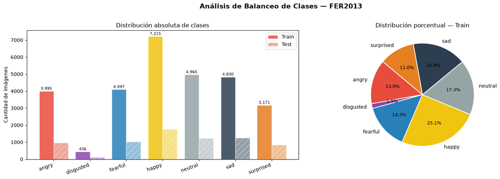

```
⚠️  Clase "disgusted" tiene solo 436 muestras vs 7,215 de "happy" (16.5x de desbalance)
```

```python
fig, axes = plt.subplots(1, 2, figsize=(16, 5))
colors = [EMOTION_COLORS[c] for c in CLASSES]

# Barras absolutas
ax = axes[0]
x = np.arange(len(CLASSES))
w = 0.4
bars1 = ax.bar(x - w/2, counts_train.values, w, label='Train', color=colors, alpha=0.85, edgecolor='white')
bars2 = ax.bar(x + w/2, counts_test.values,  w, label='Test',  color=colors, alpha=0.5,  edgecolor='white', hatch='//')
ax.set_xticks(x)
ax.set_xticklabels(CLASSES, rotation=20, ha='right')
ax.set_ylabel('Cantidad de imágenes')
ax.set_title('Distribución absoluta de clases')
ax.legend()
for bar in bars1:
    ax.text(bar.get_x() + bar.get_width()/2, bar.get_height() + 30,
            f'{int(bar.get_height()):,}', ha='center', va='bottom', fontsize=8)

# Pie chart del train
ax = axes[1]
wedges, texts, autotexts = ax.pie(
    counts_train.values,
    labels=CLASSES,
    colors=colors,
    autopct='%1.1f%%',
    startangle=140,
    wedgeprops={'edgecolor': 'white', 'linewidth': 1.5}
)
for at in autotexts:
    at.set_fontsize(9)
ax.set_title('Distribución porcentual — Train')

plt.suptitle('Análisis de Balanceo de Clases — FER2013', fontsize=14, fontweight='bold', y=1.01)
plt.tight_layout()
plt.savefig(BASE_DIR / 'fig_01_class_distribution.png', dpi=150, bbox_inches='tight')
plt.show()
print('⚠️  Clase "disgusted" tiene solo 436 muestras vs 7,215 de "happy" (16.5x de desbalance)')
```

## 1.4 — Visualización de muestras por clase

Antes de diseñar el modelo, es fundamental entender visualmente los datos: inspeccionar la calidad de las imágenes, la variabilidad intra-clase y las similitudes inter-clase (ej. *fearful* vs *surprised*).

[figure not shown]

```python
N_SAMPLES = 6  # muestras por clase

fig, axes = plt.subplots(len(CLASSES), N_SAMPLES, figsize=(N_SAMPLES * 2, len(CLASSES) * 2 + 1))

for row, cls in enumerate(CLASSES):
    subset = df_train[df_train['label'] == cls].sample(N_SAMPLES, random_state=SEED)
    for col, (_, rec) in enumerate(subset.iterrows()):
        img = np.array(Image.open(rec['path']).convert('L'))  # escala de grises
        ax = axes[row, col]
        ax.imshow(img, cmap='gray', vmin=0, vmax=255)
        ax.axis('off')
        if col == 0:
            ax.set_ylabel(cls.upper(), fontsize=10, fontweight='bold',
                         color=EMOTION_COLORS[cls], rotation=0, ha='right',
                         labelpad=60, va='center')

plt.suptitle('Muestras de entrenamiento por clase (escala de grises, 48×48 px)',
             fontsize=13, fontweight='bold')
plt.tight_layout()
plt.savefig(BASE_DIR / 'fig_02_sample_images.png', dpi=150, bbox_inches='tight')
plt.show()
```

## 1.5 — Estadísticas de las imágenes

Verificamos dimensiones, canales, y la distribución de intensidades de píxeles. Esto informa la estrategia de normalización.

```python
# Muestreo aleatorio para estadísticas (evitamos cargar las 35k imágenes)
sample_paths = df_train.sample(500, random_state=SEED)['path'].tolist()

shapes, means, stds = [], [], []
for p in sample_paths:
    img = np.array(Image.open(p).convert('L'), dtype=np.float32)
    shapes.append(img.shape)
    means.append(img.mean())
    stds.append(img.std())

unique_shapes = Counter(shapes)
GLOBAL_MEAN = np.mean(means)
GLOBAL_STD  = np.mean(stds)

print('=== Dimensiones de imágenes ===')
for shape, cnt in unique_shapes.most_common(5):
    print(f'  {shape}: {cnt} imágenes')

print(f'\n=== Estadísticas de intensidad (muestra n=500) ===')
print(f'  Media global:    {GLOBAL_MEAN:.2f}  (escala 0–255)')
print(f'  Desv. estándar:  {GLOBAL_STD:.2f}')
print(f'  Media norm.:     {GLOBAL_MEAN/255:.4f}  (escala 0–1)')
print(f'  Std norm.:       {GLOBAL_STD/255:.4f}')
print(f'\n→ Estos valores se usarán para la estandarización Z-score en el pipeline de entrenamiento.')
```

```
=== Dimensiones de imágenes ===
  (48, 48): 500 imágenes

=== Estadísticas de intensidad (muestra n=500) ===
  Media global:    129.99  (escala 0–255)
  Desv. estándar:  52.87
  Media norm.:     0.5098  (escala 0–1)
  Std norm.:       0.2073

→ Estos valores se usarán para la estandarización Z-score en el pipeline de entrenamiento.
```

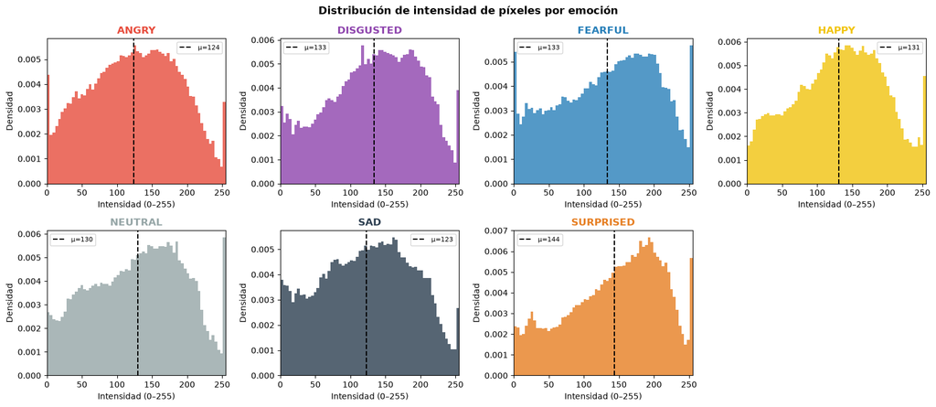

```python
# Histogramas de distribución de píxeles por clase
fig, axes = plt.subplots(2, 4, figsize=(16, 7))
axes = axes.flatten()

for i, cls in enumerate(CLASSES):
    subset = df_train[df_train['label'] == cls].sample(min(100, counts_train[cls]), random_state=SEED)
    pixels = []
    for p in subset['path']:
        img = np.array(Image.open(p).convert('L'), dtype=np.float32)
        pixels.extend(img.flatten().tolist())
    ax = axes[i]
    ax.hist(pixels, bins=64, color=EMOTION_COLORS[cls], alpha=0.8, edgecolor='none', density=True)
    ax.axvline(np.mean(pixels), color='black', lw=1.5, linestyle='--', label=f'μ={np.mean(pixels):.0f}')
    ax.set_title(cls.upper(), fontweight='bold', color=EMOTION_COLORS[cls])
    ax.set_xlabel('Intensidad (0–255)')
    ax.set_ylabel('Densidad')
    ax.legend(fontsize=8)
    ax.set_xlim(0, 255)

axes[-1].axis('off')  # la celda 8 queda vacía
plt.suptitle('Distribución de intensidad de píxeles por emoción', fontsize=13, fontweight='bold')
plt.tight_layout()
plt.savefig(BASE_DIR / 'fig_03_pixel_histograms.png', dpi=150, bbox_inches='tight')
plt.show()
```

## 1.6 — Análisis en el Dominio Frecuencial (FFT 2D)

> **Conexión con la materia:** En clase estudiamos la Transformada de Fourier para analizar señales en el dominio de la frecuencia. La misma lógica aplica a imágenes 2D: la FFT 2D descompone la imagen en sus componentes de frecuencia espacial. Las **bajas frecuencias** (centro del espectro) representan la estructura general del rostro; las **altas frecuencias** (bordes del espectro) representan los bordes, arrugas y texturas finas. Analizar el espectro promedio por emoción nos permite ver si las diferentes emociones difieren en su contenido de alta frecuencia (movimientos musculares finos).

Este análisis equivale a lo que se estudia en `Clase_Dominio_Frecuencia_PSUTN.pdf` y `Clase_Tiempo_Frecuencia_PSUTN.pdf`, pero aplicado al espacio 2D.

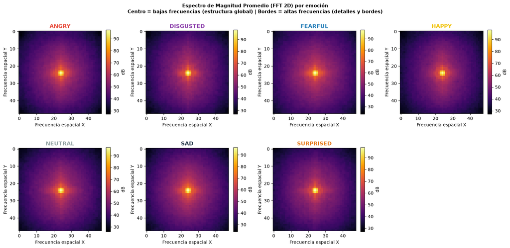

```python
def compute_avg_magnitude_spectrum(paths, n=80):
    """Calcula el espectro de magnitud promedio (en dB) de una lista de imágenes."""
    spectra = []
    for p in random.sample(paths, min(n, len(paths))):
        img = np.array(Image.open(p).convert('L'), dtype=np.float32)
        # Ventana de Hanning para reducir el efecto de borde (como en señales 1D)
        h_win = np.hanning(img.shape[0])[:, None]
        v_win = np.hanning(img.shape[1])[None, :]
        windowed = img * h_win * v_win
        f = np.fft.fft2(windowed)
        fshift = np.fft.fftshift(f)
        magnitude = 20 * np.log10(np.abs(fshift) + 1e-8)
        spectra.append(magnitude)
    return np.mean(spectra, axis=0)

fig, axes = plt.subplots(2, 4, figsize=(16, 8))
axes = axes.flatten()

for i, cls in enumerate(CLASSES):
    paths = df_train[df_train['label'] == cls]['path'].tolist()
    avg_spectrum = compute_avg_magnitude_spectrum(paths)
    ax = axes[i]
    im = ax.imshow(avg_spectrum, cmap='inferno', origin='upper')
    ax.set_title(f'{cls.upper()}', fontweight='bold', color=EMOTION_COLORS[cls])
    ax.set_xlabel('Frecuencia espacial X')
    ax.set_ylabel('Frecuencia espacial Y')
    plt.colorbar(im, ax=ax, fraction=0.046, label='dB')

axes[-1].axis('off')
plt.suptitle(
    'Espectro de Magnitud Promedio (FFT 2D) por emoción\n'
    'Centro = bajas frecuencias (estructura global) | Bordes = altas frecuencias (detalles y bordes)',
    fontsize=11, fontweight='bold'
)
plt.tight_layout()
plt.savefig(BASE_DIR / 'fig_04_fft_spectra.png', dpi=150, bbox_inches='tight')
plt.show()
```

## 1.7 — Filtrado espacial: Gaussiano y Sobel

> **Conexión con la materia:** En `Clase_Filtrado_DF_PSUTN.pdf` y `Clase_Filtrado_MA_PSUTN.pdf` vimos que los filtros actúan como pesos que se aplican via **convolución** sobre la señal. En imágenes 2D:
> - **Filtro Gaussiano** (equivalente a media móvil 2D ponderada): suaviza la imagen eliminando ruido de alta frecuencia. Es un **filtro pasa-bajos** espacial.
> - **Filtro Sobel** (diferenciador): detecta bordes calculando el gradiente de la imagen. Es un **filtro pasa-altos** espacial.

> La operación es exactamente la **convolución 2D** definida en `Clase_Convol_Correl_PSUTN.pdf`: $$(f * g)[m,n] = \sum_{k} \sum_{l} f[k,l] \cdot g[m-k, n-l]$$ Las CNN aprenden automáticamente estos kernels de convolución durante el entrenamiento.

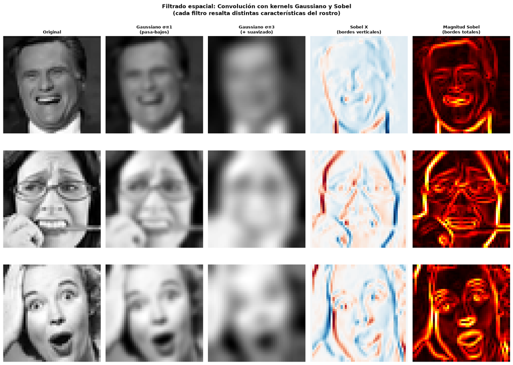

```python
# Elegimos una muestra de cada clase para visualizar los efectos de filtrado
sample_per_class = {
    cls: np.array(Image.open(
        df_train[df_train['label'] == cls].sample(1, random_state=SEED)['path'].values[0]
    ).convert('L'), dtype=np.float32)
    for cls in CLASSES
}

# Kernels de convolución usados en filtrado
kernel_sobel_x = np.array([[-1, 0, 1], [-2, 0, 2], [-1, 0, 1]], dtype=np.float32)
kernel_sobel_y = np.array([[-1,-2,-1], [ 0, 0, 0], [ 1, 2, 1]], dtype=np.float32)

# Visualización para 3 emociones representativas
selected = ['happy', 'fearful', 'surprised']
fig, axes = plt.subplots(len(selected), 5, figsize=(16, 4 * len(selected)))

col_titles = ['Original', 'Gaussiano σ=1\n(pasa-bajos)', 'Gaussiano σ=3\n(+ suavizado)',
              'Sobel X\n(bordes verticales)', 'Magnitud Sobel\n(bordes totales)']

for row, cls in enumerate(selected):
    img = sample_per_class[cls]

    gauss1    = cv2.GaussianBlur(img, (5,5), sigmaX=1.0)
    gauss3    = cv2.GaussianBlur(img, (11,11), sigmaX=3.0)
    sobel_x   = cv2.filter2D(img, -1, kernel_sobel_x)
    sobel_y   = cv2.filter2D(img, -1, kernel_sobel_y)
    sobel_mag = np.sqrt(sobel_x**2 + sobel_y**2)

    imgs = [img, gauss1, gauss3, sobel_x, sobel_mag]
    cmaps = ['gray','gray','gray','RdBu_r','hot']

    for col, (im, cmap) in enumerate(zip(imgs, cmaps)):
        ax = axes[row, col]
        ax.imshow(im, cmap=cmap)
        ax.axis('off')
        if row == 0:
            ax.set_title(col_titles[col], fontsize=9, fontweight='bold')
        if col == 0:
            ax.set_ylabel(cls.upper(), fontsize=10, fontweight='bold',
                         color=EMOTION_COLORS[cls], rotation=0, ha='right',
                         labelpad=65, va='center')

plt.suptitle('Filtrado espacial: Convolución con kernels Gaussiano y Sobel\n'
             '(cada filtro resalta distintas características del rostro)',
             fontsize=12, fontweight='bold')
plt.tight_layout()
plt.savefig(BASE_DIR / 'fig_05_spatial_filtering.png', dpi=150, bbox_inches='tight')
plt.show()
```

[figure not shown]

```python
def mean_image_and_variance(paths, n=50):
    """Calcula la imagen promedio y varianza pixelwise de una muestra."""
    imgs = []
    for p in random.sample(paths, min(n, len(paths))):
        img = np.array(Image.open(p).convert('L').resize((48,48)), dtype=np.float32) / 255.0
        imgs.append(img)
    stack = np.stack(imgs, axis=0)
    return stack.mean(axis=0), stack.std(axis=0)

fig, axes = plt.subplots(2, len(CLASSES), figsize=(18, 6))

for col, cls in enumerate(CLASSES):
    paths = df_train[df_train['label'] == cls]['path'].tolist()
    mean_img, std_img = mean_image_and_variance(paths)

    axes[0, col].imshow(mean_img, cmap='gray', vmin=0, vmax=1)
    axes[0, col].set_title(cls.upper(), fontsize=9, fontweight='bold', color=EMOTION_COLORS[cls])
    axes[0, col].axis('off')

    im = axes[1, col].imshow(std_img, cmap='hot', vmin=0, vmax=0.3)
    axes[1, col].axis('off')

axes[0, 0].set_ylabel('Imagen\nPromedio', fontsize=9, rotation=0, ha='right', labelpad=55)
axes[1, 0].set_ylabel('Varianza\nPixelwise\n(diversidad)', fontsize=9, rotation=0, ha='right', labelpad=55)

plt.suptitle('Imagen promedio y varianza por clase\n'
             'Alta varianza (zonas rojas) = mayor diversidad intra-clase = zona de información',
             fontsize=11, fontweight='bold')
plt.tight_layout()
plt.savefig(BASE_DIR / 'fig_06_mean_variance_per_class.png', dpi=150, bbox_inches='tight')
plt.show()
```

## 1.9 — Data Augmentation

La augmentation sirve para dos propósitos:

1. **Aumentar artificialmente el tamaño del dataset**, especialmente para la clase minoritaria (`disgusted`).
2. **Mejorar la generalización** del modelo al exponer variantes de la misma imagen durante el entrenamiento.

Las transformaciones se aplican **solo en train**, nunca en test.

```python
import albumentations as A

# Pipeline de augmentation para ENTRENAMIENTO
# Cada transformación tiene una probabilidad de aplicarse
augmentation_train = A.Compose([
    A.HorizontalFlip(p=0.5),                        # Espejo horizontal (neutral para emociones)
    A.Rotate(limit=15, p=0.5),                      # Pequeña rotación (±15°)
    A.RandomBrightnessContrast(
        brightness_limit=0.2,
        contrast_limit=0.2,
        p=0.6
    ),                                              # Variaciones de iluminación
    A.GaussNoise(var_limit=(5, 25), p=0.3),        # Ruido gaussiano leve
    A.Affine(
        shear=(-5, 5),
        translate_percent=(-0.05, 0.05),
        p=0.4
    ),                                              # Pequeño desplazamiento y shear
    A.Normalize(mean=[GLOBAL_MEAN/255], std=[GLOBAL_STD/255]),  # Z-score normalización
])

# Pipeline de preprocesamiento para VALIDACIÓN y TEST (sin augmentation)
augmentation_test = A.Compose([
    A.Normalize(mean=[GLOBAL_MEAN/255], std=[GLOBAL_STD/255]),
])

print('Pipeline de augmentation (train):')
for t in augmentation_train.transforms:
    print(f'  • {t.__class__.__name__}')
print('\nPipeline de preprocesamiento (val/test):')
for t in augmentation_test.transforms:
    print(f'  • {t.__class__.__name__}')
```

```
Pipeline de augmentation (train):
  • HorizontalFlip
  • Rotate
  • RandomBrightnessContrast
  • GaussNoise
  • Affine
  • Normalize

Pipeline de preprocesamiento (val/test):
  • Normalize
```

[figure not shown]

```python
# Visualización del efecto de la augmentation sobre una imagen real
img_sample = np.array(
    Image.open(df_train[df_train['label'] == 'happy'].sample(1, random_state=5)['path'].values[0]).convert('L'),
    dtype=np.uint8
)

# Augmentation raw (sin normalizar) para visualización
aug_viz = A.Compose([
    A.HorizontalFlip(p=0.5),
    A.Rotate(limit=15, p=1.0),
    A.RandomBrightnessContrast(brightness_limit=0.3, contrast_limit=0.3, p=1.0),
    A.GaussNoise(var_limit=(10,40), p=1.0),
])

n_aug = 8
fig, axes = plt.subplots(1, n_aug + 1, figsize=(18, 2.5))

axes[0].imshow(img_sample, cmap='gray')
axes[0].set_title('Original', fontweight='bold')
axes[0].axis('off')

random.seed(None)  # variabilidad en la visualización
for i in range(1, n_aug + 1):
    augmented = aug_viz(image=img_sample)['image']
    axes[i].imshow(augmented, cmap='gray')
    axes[i].set_title(f'Aug #{i}', fontsize=9)
    axes[i].axis('off')

plt.suptitle('Efecto de Data Augmentation — clase HAPPY\n'
             'Cada imagen aumentada es una vista diferente del mismo rostro',
             fontsize=11, fontweight='bold')
plt.tight_layout()
plt.savefig(BASE_DIR / 'fig_07_augmentation_examples.png', dpi=150, bbox_inches='tight')
plt.show()
random.seed(SEED)  # restauramos la semilla
```

## 1.10 — Normalización / Estandarización

Implementamos y comparamos las dos estrategias de escalado más comunes:

| Estrategia | Fórmula | Cuándo usarla |
| --- | --- | --- |
| **Min-Max** | $x' = x / 255$ | Rango $[0,1]$, simple, para redes con activación Sigmoid |
| **Z-Score** | $x' = (x - \mu) / \sigma$ | Media 0, std 1, para redes con BatchNorm (nuestra elección) |

**Usaremos Z-Score** con los estadísticos del dataset calculados en §1.5, incorporados en el pipeline de Albumentations.

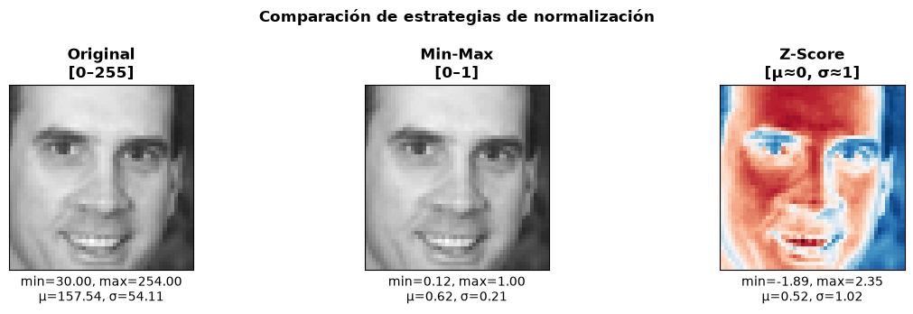

```python
# Comparación visual de las estrategias de normalización
img_f = img_sample.astype(np.float32)

img_minmax = img_f / 255.0
img_zscore = (img_f - GLOBAL_MEAN) / (GLOBAL_STD + 1e-8)

fig, axes = plt.subplots(1, 3, figsize=(12, 3.5))

data_pairs = [
    (img_f,      'Original\n[0–255]',       'gray',   (0, 255)),
    (img_minmax, 'Min-Max\n[0–1]',           'gray',   (0, 1)),
    (img_zscore, f'Z-Score\n[μ≈0, σ≈1]',     'RdBu_r', None),
]

for ax, (im, title, cmap, vrange) in zip(axes, data_pairs):
    kwargs = {'cmap': cmap}
    if vrange:
        kwargs['vmin'], kwargs['vmax'] = vrange
    ax.imshow(im, **kwargs)
    ax.set_title(title, fontweight='bold')
    ax.set_xlabel(f'min={im.min():.2f}, max={im.max():.2f}\nμ={im.mean():.2f}, σ={im.std():.2f}')
    ax.set_xticks([]); ax.set_yticks([])

plt.suptitle('Comparación de estrategias de normalización', fontsize=12, fontweight='bold')
plt.tight_layout()
plt.savefig(BASE_DIR / 'fig_08_normalization_comparison.png', dpi=150, bbox_inches='tight')
plt.show()
```

## 1.11 — División train / validación y Dataset de PyTorch

Separamos un conjunto de validación (20% del train) con **stratify** para mantener la proporción de clases. Esto es fundamental con el desbalance que detectamos.

```python
from sklearn.preprocessing import LabelEncoder
from sklearn.model_selection import train_test_split

# Encode de etiquetas
le = LabelEncoder()
le.fit(CLASSES)
df_train['label_enc'] = le.transform(df_train['label'])
df_test['label_enc']  = le.transform(df_test['label'])

# Split estratificado train → train + val
df_tr, df_val = train_test_split(
    df_train,
    test_size=0.2,
    random_state=SEED,
    stratify=df_train['label']
)
df_tr  = df_tr.reset_index(drop=True)
df_val = df_val.reset_index(drop=True)

print(f'Train efectivo:    {len(df_tr):,} imágenes')
print(f'Validación:        {len(df_val):,} imágenes')
print(f'Test (hold-out):   {len(df_test):,} imágenes')
print(f'\nDistribución en validación:')
print(df_val['label'].value_counts().to_string())
```

```
Train efectivo:    22,967 imágenes
Validación:        5,742 imágenes
Test (hold-out):   7,178 imágenes

Distribución en validación:
label
happy        1443
neutral       993
sad           966
fearful       820
angry         799
surprised     634
disgusted      87
```

```python
# Guardar los DataFrames para reutilizar en los pasos 2 y 3
df_tr.to_csv(BASE_DIR / 'df_train_split.csv',      index=False)
df_val.to_csv(BASE_DIR / 'df_val_split.csv',       index=False)
df_test.to_csv(BASE_DIR / 'df_test_split.csv',     index=False)

# Guardar estadísticos de normalización
norm_stats = pd.DataFrame({'mean': [GLOBAL_MEAN/255], 'std': [GLOBAL_STD/255]})
norm_stats.to_csv(BASE_DIR / 'normalization_stats.csv', index=False)

print('Archivos guardados:')
for f in ['df_train_split.csv', 'df_val_split.csv', 'df_test_split.csv', 'normalization_stats.csv']:
    print(f'  ✓ {f}')
```

```
Archivos guardados:
  ✓ df_train_split.csv
  ✓ df_val_split.csv
  ✓ df_test_split.csv
  ✓ normalization_stats.csv
```

```python
# Dataset class de PyTorch — reutilizable en los pasos 2 y 3
try:
    import torch
    from torch.utils.data import Dataset, DataLoader
    TORCH_AVAILABLE = True
except ImportError:
    TORCH_AVAILABLE = False
    print('PyTorch no instalado — se omite la definición del Dataset. Instalar con: pip install torch torchvision')

if TORCH_AVAILABLE:
    class EmotionDataset(Dataset):
        """
        Dataset de PyTorch para FER2013.
        Carga imágenes on-the-fly desde disco con augmentation configurable.
        """
        def __init__(self, dataframe: pd.DataFrame, transform=None):
            self.df = dataframe.reset_index(drop=True)
            self.transform = transform

        def __len__(self):
            return len(self.df)

        def __getitem__(self, idx):
            row = self.df.iloc[idx]
            img = np.array(Image.open(row['path']).convert('L'), dtype=np.uint8)
            if self.transform:
                img = self.transform(image=img)['image']
            # Canal único → shape (1, H, W)
            img_tensor = torch.tensor(img, dtype=torch.float32).unsqueeze(0)
            label = torch.tensor(row['label_enc'], dtype=torch.long)
            return img_tensor, label

    # Verificación rápida
    ds_test_check = EmotionDataset(df_tr.head(10), transform=augmentation_train)
    img_t, lbl_t = ds_test_check[0]
    print(f'EmotionDataset OK — tensor shape: {img_t.shape}, dtype: {img_t.dtype}, label: {lbl_t.item()} ({le.classes_[lbl_t.item()]})')
```

```
PyTorch no instalado — se omite la definición del Dataset. Instalar con: pip install torch torchvision
```

## 1.12 — Cálculo de pesos de clase (para compensar el desbalance)

En lugar de oversamplear la clase `disgusted`, podemos pasarle a PyTorch pesos inversamente proporcionales a la frecuencia de cada clase. Así el optimizador "penaliza más" los errores en clases raras.

```python
# Pesos inversamente proporcionales a la frecuencia
class_counts = df_tr['label_enc'].value_counts().sort_index()
class_weights = 1.0 / class_counts.values.astype(np.float32)
class_weights = class_weights / class_weights.sum() * len(CLASSES)  # normalizar

print('Pesos por clase para la función de pérdida (CrossEntropyLoss weight=...):')
for cls, w in zip(le.classes_, class_weights):
    bar = '█' * int(w * 10)
    print(f'  {cls:12s}: {w:.4f}  {bar}')

if TORCH_AVAILABLE:
    CLASS_WEIGHTS_TENSOR = torch.tensor(class_weights, dtype=torch.float32)
    print(f'\ntorch.Tensor listo: {CLASS_WEIGHTS_TENSOR}')
```

```
Pesos por clase para la función de pérdida (CrossEntropyLoss weight=...):
  angry       : 0.4802  ████
  disgusted   : 4.3972  ███████████████████████████████████████████
  fearful     : 0.4683  ████
  happy       : 0.2659  ██
  neutral     : 0.3864  ███
  sad         : 0.3972  ███
  surprised   : 0.6049  ██████
```

## 1.13 — Resumen del Paso 1

[output not shown]

### Próximos pasos

- **Paso 2:** Diseño y entrenamiento de la CNN / Transfer Learning con los pipelines definidos aquí
- **Paso 3:** Uso del encoder del Paso 2 como extractor de features para XGBoost
- **Paso 4:** Evaluación comparativa con ROC-AUC y Matriz de Confusión
- **Paso 5:** SHAP Values y Grad-CAM para interpretabilidad